# Generalized linear mixed effects regression

import des libraries

```r
library(lme4)
library(dplyr)
library(readxl)
library(stringr)
library(tidyr)
```

```r
library(ggplot2)
```

import des données

```r
df <- read_excel("Data_salive_steroides_cinetique.xlsx")
head(df)
```

```
## # A tibble: 6 × 87
##   PATIENT Groupe          `Patient number` Forme       `Nombre de prises` Gender
##   <chr>   <chr>                      <dbl> <chr>                    <dbl> <chr>
## 1 P1_T1   Gp contrôlé                    1 Pure viril…                  1 F
## 2 P1_T2   Gp contrôlé                    1 Pure viril…                  1 F
## 3 P1_T3   Gp non contrôlé                1 Pure viril…                  3 F
## 4 P1_T4   Gp non contrôlé                1 Pure viril…                  2 F
## 5 P1_T5   Gp non contrôlé                1 Pure viril…                  3 F
## 6 P1_T6   Gp contrôlé                    1 Pure viril…                  2 F
## # ℹ 81 more variables: `Puberty stage` <dbl>, `8h_ALDOSTERONE` <dbl>,
## #   `8h_ANDROSTENEDIONE` <dbl>, `8h_TESTOSTERONE` <dbl>, `8h_5 ADHT` <dbl>,
## #   `8h_PREGNENOLONE` <dbl>, `8h_11 BOH4` <dbl>, `8h_17OH-PREGNENOLONE` <dbl>,
## #   `8h_PROGESTERONE` <dbl>, `8h_21DB` <dbl>, `8h_DOC` <dbl>, `8h_17OHP` <dbl>,
## #   `8h_21DF` <dbl>, `8h_CORTICOSTERONE` <dbl>, `8h_11DF` <dbl>,
## #   `8h_CORTISONE` <dbl>, `8h_DHEA` <dbl>, `8h_11 CETOTESTO` <dbl>,
## #   `8h_11 BOHTESTO` <dbl>, `8h_16OHP` <dbl>, `8h_21DE` <dbl>, …
```

On passe en format long pour donner le temps de la journée au modèle. On va d’abord se concentrer sur un seul stéroide pour commencer, ici 17OHP.

```r
df <- df %>%
  pivot_longer(
    cols = c(`8h_17OHP`, `12h_17OHP`, `16h_17OHP`, `20h_17OHP`),
    names_to = "Time",
    values_to = "steroid_17OHP"
  ) %>%
  mutate(
    # Nettoyer l'heure pour avoir un truc propre
    Time = factor(Time,
                  levels = c("8h_17OHP", "12h_17OHP", "16h_17OHP", "20h_17OHP"),
                  labels = c("8", "12", "16", "20")),
    Groupe_bin = ifelse(Groupe == "Gp non contrôlé", 1, 0),
    Groupe_bin = factor(Groupe_bin),
    Gender = factor(Gender),
    `Puberty stage` = factor(`Puberty stage`),
    Patient_number = factor(`Patient number`)
  )
```

On enlève l’instabilité (on a pas assez de donnée et les données sont trop disperses sur Puberté, donc on coupe en 2 cas pour + de stabilité)

```r
df <- df %>%
  mutate(
    Puberty_stage_simple = case_when(
      `Puberty stage` %in% c(1, 2) ~ "prepubertal",
      TRUE ~ "pubertal"
    ),
    Puberty_stage_simple = factor(Puberty_stage_simple)
  )
```

Comme on s’intérèsse que au 17OHP pour l’instant, on garde que ce qui nous intéresse:

```r
df_d<- df %>%
  select(Patient_number, Gender, Puberty_stage_simple,
         Time, steroid_17OHP, Groupe_bin)
```

On va déjà peut être un peu voir à quoi ressemble les données.

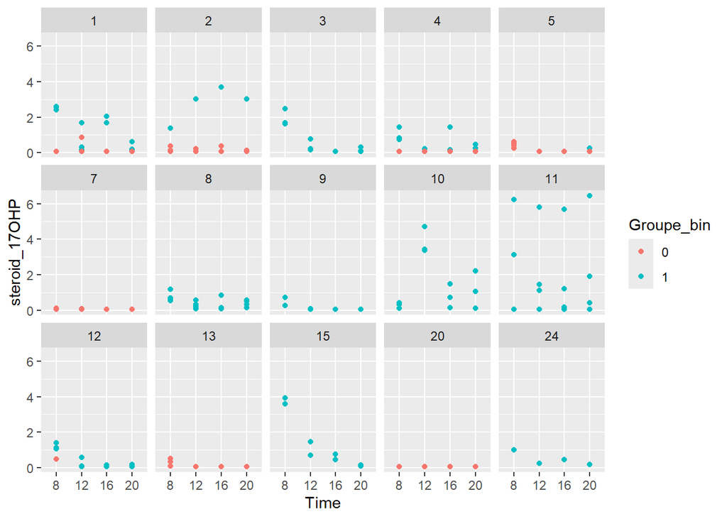

```r
ggplot(df_d, aes(x = Time, y =  steroid_17OHP, color=Groupe_bin)) +
  geom_point()+facet_wrap(facets = vars(Patient_number), nrow = 3)
```

**0 == contrôlé** **1 == non contrôlé** On voit clairement une différence de valeurs entre le groupe contrôlé et le groupe non contrôlé. On a néanmoins des cas plus compliqués comme le patient 9 qui à priori devrait être contrôlé. Il faut prendre en considération le fait qu’on ne mesure pas que du 17OHP et que vraisemblablement d’autres hormones sont en cause.

*TO DO: voir Patient 9*

Beaucoup de valeurs sont à 0.06, c’est vraisemblablement la limite de l’appareil médical qui mesure probablement des valeurs en dessous 0.06 (c’est donc le plancher de l’appareil).

On va maintenant lancer le modèle.

```r
mod_17ohp <- glmer(
  Groupe_bin ~ log(steroid_17OHP + 1e-6) +
    Gender  + Puberty_stage_simple+
    (1 | Patient_number),
  data = df_d,
  family = binomial,
  control = glmerControl(optimizer = "bobyqa")
)
summary(mod_17ohp)
```

```
## Generalized linear mixed model fit by maximum likelihood (Laplace
##   Approximation) [glmerMod]
##  Family: binomial  ( logit )
## Formula:
## Groupe_bin ~ log(steroid_17OHP + 1e-06) + Gender + Puberty_stage_simple +
##     (1 | Patient_number)
##    Data: df_d
## Control: glmerControl(optimizer = "bobyqa")
##
##       AIC       BIC    logLik -2*log(L)  df.resid
##     112.6     128.9     -51.3     102.6       185
##
## Scaled residuals:
##     Min      1Q  Median      3Q     Max
## -4.9826 -0.1861  0.0122  0.1573  4.0090
##
## Random effects:
##  Groups         Name        Variance Std.Dev.
##  Patient_number (Intercept) 8.315    2.884
## Number of obs: 190, groups:  Patient_number, 14
##
## Fixed effects:
##                              Estimate Std. Error z value Pr(>|z|)
## (Intercept)                   -1.2455     2.3861  -0.522   0.6017
## log(steroid_17OHP + 1e-06)     1.3489     0.2984   4.520 6.18e-06 ***
## GenderM                        7.0147     3.1754   2.209   0.0272 *
## Puberty_stage_simplepubertal   5.1555     2.7165   1.898   0.0577 .
## ---
## Signif. codes:  0 '***' 0.001 '**' 0.01 '*' 0.05 '.' 0.1 ' ' 1
##
## Correlation of Fixed Effects:
##             (Intr) l(_1+1 GendrM
## l(_17OHP+1-  0.169
## GenderM     -0.661  0.092
## Pbrty_stg_s -0.846  0.088  0.612
```

On voit que le steroid a un effet très significatif pour prédire le groupe. Gender importe aussi même si beaucoup moins que 17OHP.

```r
ranef(mod_17ohp)
```

```
## $Patient_number
##    (Intercept)
## 1  -1.41781729
## 2  -3.67653977
## 3   0.03189694
## 4  -0.17387840
## 5   2.26336715
## 7  -3.47753665
## 8   2.37723550
## 9   2.58352977
## 10  1.71418989
## 11  0.03430979
## 12 -1.57839424
## 13 -0.84661256
## 15  0.00654145
## 24  0.37366790
##
## with conditional variances for "Patient_number"
```

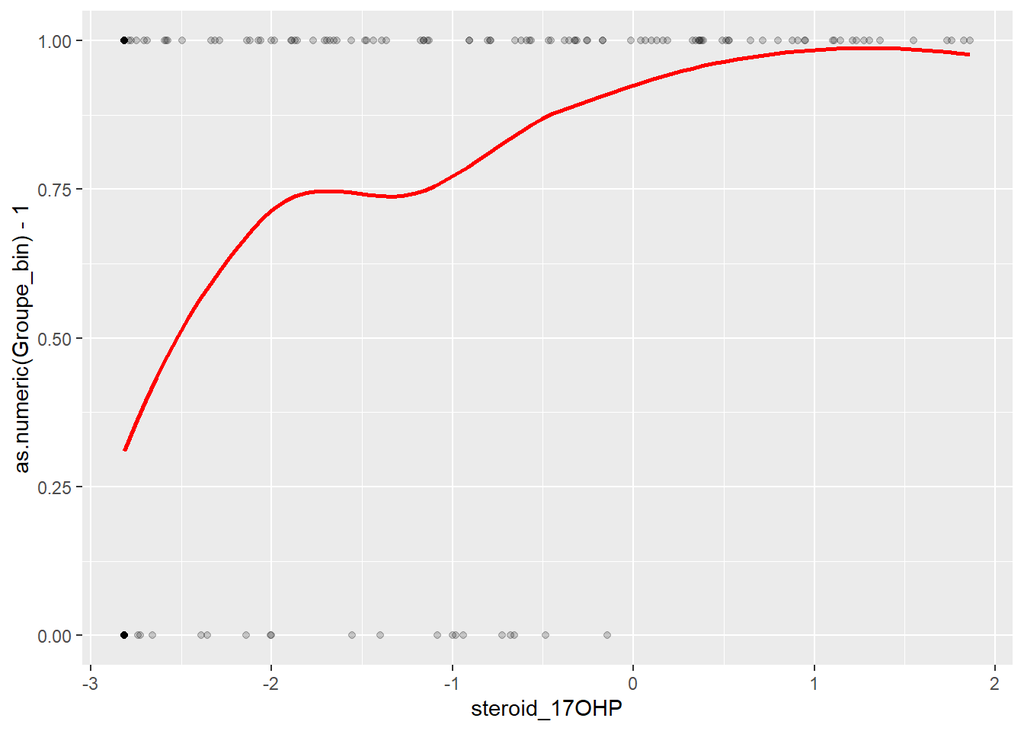

```r
df_model <- model.frame(mod_17ohp)# uniquement les lignes complètes

df_model$steroid_17OHP <- model.frame(mod_17ohp)[[ "log(steroid_17OHP + 1e-06)" ]]
df_model$fitted <- fitted(mod_17ohp)
df_model$prob <- fitted(mod_17ohp)

df_model <- df_model[order(df_model$steroid_17OHP), ]
# Plot
library(ggplot2)
ggplot(df_model, aes(x = steroid_17OHP, y = prob)) +
  geom_point(aes(y = as.numeric(Groupe_bin)-1), alpha = 0.2) +
  geom_smooth(method = "loess", se = FALSE, color = "red", span = 0.8)
```